# Predicting Boston’s Bikeshare Ridership

## Discussion

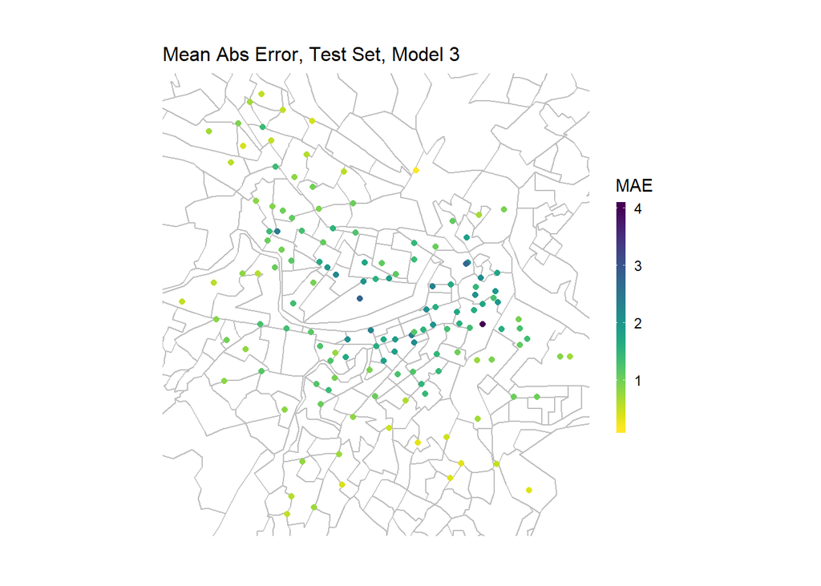

```r
week_predictions %>%
  mutate(interval60 = map(data, pull, interval60),
         start.station.id = map(data, pull, start.station.id),
         start.station.latitude = map(data, pull, start.station.latitude),
         start.station.longitude = map(data, pull, start.station.longitude)) %>%
  select(interval60, start.station.id, start.station.longitude, start.station.latitude, Observed, Prediction, Regression) %>%
  unnest() %>%
  filter(Regression == "CTime_Space_FE_timeLags") %>%
  group_by(start.station.id, start.station.longitude, start.station.latitude) %>%
  summarize(MAE = mean(abs(Observed-Prediction), na.rm = TRUE))%>%
  ggplot(.)+
  geom_sf(data = bostonCensus, color = "grey", fill = "transparent")+
  geom_point(aes(x = start.station.longitude, y = start.station.latitude, color = MAE),
             fill = "transparent", alpha = 1)+
  scale_colour_viridis(direction = -1,
                       discrete = FALSE, option = "D")+
  ylim(min(dat_census$start.station.latitude), max(dat_census$start.station.latitude))+
  xlim(min(dat_census$start.station.longitude), max(dat_census$start.station.longitude))+
  labs(title="Mean Abs Error, Test Set, Model 3")+
  mapTheme
```

The model works better on the weekends and during days when ridership is more standardized (mid-day and overnight). It struggles specifically in the PM rush because the relatively higher ridership.

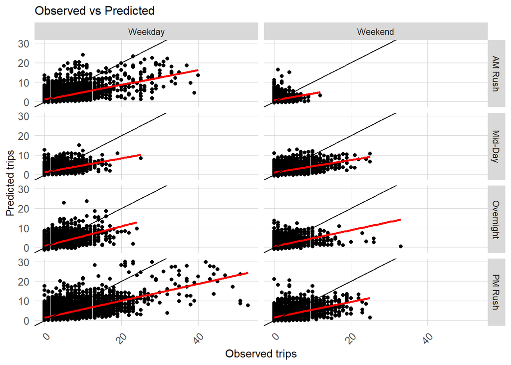

```r
week_predictions %>%
  mutate(interval60 = map(data, pull, interval60),
         start.station.id = map(data, pull, start.station.id),
         start.station.latitude = map(data, pull, start.station.latitude),
         start.station.longitude = map(data, pull, start.station.longitude),
         dotw = map(data, pull, dotw)) %>%
  select(interval60, start.station.id, start.station.longitude,
         start.station.latitude, Observed, Prediction, Regression,
         dotw) %>%
  unnest() %>%
  filter(Regression == "CTime_Space_FE_timeLags")%>%
  mutate(weekend = ifelse(dotw %in% c("Sun", "Sat"), "Weekend", "Weekday"),
         time_of_day = case_when(hour(interval60) < 7 | hour(interval60) > 18 ~ "Overnight",
                                 hour(interval60) >= 7 & hour(interval60) < 10 ~ "AM Rush",
                                 hour(interval60) >= 10 & hour(interval60) < 15 ~ "Mid-Day",
                                 hour(interval60) >= 15 & hour(interval60) <= 18 ~ "PM Rush"))%>%
  ggplot()+
  geom_point(aes(x= Observed, y = Prediction))+
  geom_smooth(aes(x= Observed, y= Prediction), method = "lm", se = FALSE, color = "red")+
  geom_abline(slope = 1, intercept = 0)+
  facet_grid(time_of_day~weekend)+
  labs(title="Observed vs Predicted",
       x="Observed trips",
       y="Predicted trips")+
  plotTheme
```

Displaying the data spatially confirms both of the known error trends regarding the central business district and PM peak period.

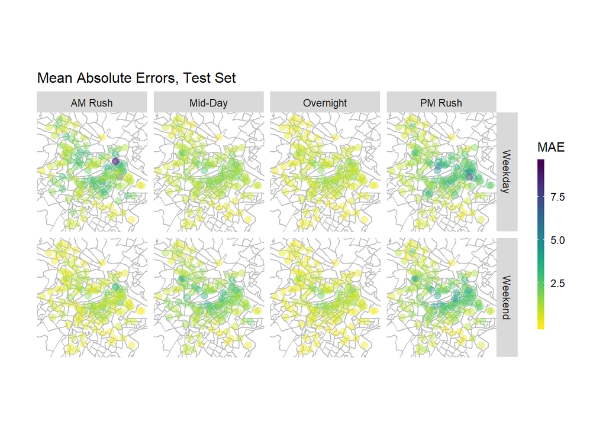

```r
week_predictions %>%
  mutate(interval60 = map(data, pull, interval60),
         start.station.id = map(data, pull, start.station.id),
         start.station.latitude = map(data, pull, start.station.latitude),
         start.station.longitude = map(data, pull, start.station.longitude),
         dotw = map(data, pull, dotw) ) %>%
  select(interval60, start.station.id, start.station.longitude,
         start.station.latitude, Observed, Prediction, Regression,
         dotw) %>%
  unnest() %>%
  filter(Regression == "CTime_Space_FE_timeLags")%>%
  mutate(weekend = ifelse(dotw %in% c("Sun", "Sat"), "Weekend", "Weekday"),
         time_of_day = case_when(hour(interval60) < 7 | hour(interval60) > 18 ~ "Overnight",
                                 hour(interval60) >= 7 & hour(interval60) < 10 ~ "AM Rush",
                                 hour(interval60) >= 10 & hour(interval60) < 15 ~ "Mid-Day",
                                 hour(interval60) >= 15 & hour(interval60) <= 18 ~ "PM Rush")) %>%
  group_by(start.station.id, weekend, time_of_day, start.station.longitude, start.station.latitude) %>%
  summarize(MAE = mean(abs(Observed-Prediction), na.rm = TRUE))%>%
  ggplot(.)+
  geom_sf(data = bostonCensus, color = "grey", fill = "transparent")+
  geom_point(aes(x = start.station.longitude, y = start.station.latitude, color = MAE),
             fill = "transparent", size = 2.5, alpha = 0.4)+
  scale_colour_viridis(direction = -1,
                       discrete = FALSE, option = "D")+
  ylim(min(dat_census$start.station.latitude), max(dat_census$start.station.latitude))+
  xlim(min(dat_census$start.station.longitude), max(dat_census$start.station.longitude))+
  facet_grid(weekend~time_of_day)+
  labs(title="Mean Absolute Errors, Test Set")+
  mapTheme
```

Across some socioeconomic variables, the models errors are distributed. One area where the model struggles is in census tracts where the share of the population that identifies as white is a super majority or greater. This may be because census data pertaining to race deals with those that live in the census tract, however there are plenty of trips that are generated by people who do not live in the tract (ex: commute home from work).

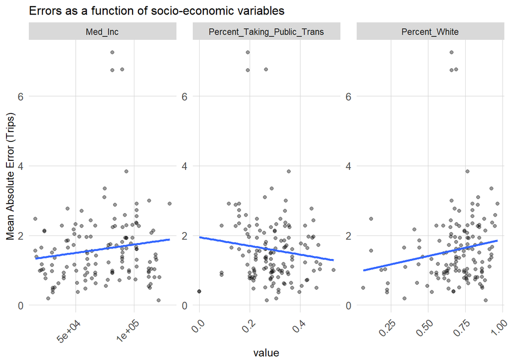

```r
week_predictions %>%
  mutate(interval60 = map(data, pull, interval60),
         start.station.id = map(data, pull, start.station.id),
         start.station.latitude = map(data, pull, start.station.latitude),
         start.station.longitude = map(data, pull, start.station.longitude),
         dotw = map(data, pull, dotw),
         Percent_Taking_Public_Trans = map(data, pull, Percent_Taking_Public_Trans),
         Med_Inc = map(data, pull, Med_Inc),
         Percent_White = map(data, pull, Percent_White)) %>%
  select(interval60, start.station.id, start.station.longitude,
         start.station.latitude, Observed, Prediction, Regression,
         dotw, Percent_Taking_Public_Trans, Med_Inc, Percent_White) %>%
  unnest() %>%
  filter(Regression == "CTime_Space_FE_timeLags")%>%
  mutate(weekend = ifelse(dotw %in% c("Sun", "Sat"), "Weekend", "Weekday"),
         time_of_day = case_when(hour(interval60) < 7 | hour(interval60) > 18 ~ "Overnight",
                                 hour(interval60) >= 7 & hour(interval60) < 10 ~ "AM Rush",
                                 hour(interval60) >= 10 & hour(interval60) < 15 ~ "Mid-Day",
                                 hour(interval60) >= 15 & hour(interval60) <= 18 ~ "PM Rush")) %>%
  filter(time_of_day == "AM Rush") %>%
  group_by(start.station.id, Percent_Taking_Public_Trans, Med_Inc, Percent_White) %>%
  summarize(MAE = mean(abs(Observed-Prediction), na.rm = TRUE))%>%
  gather(-start.station.id, -MAE, key = "variable", value = "value")%>%
  ggplot(.)+
  #geom_sf(data = bostonCensus, color = "grey", fill = "transparent")+
  geom_point(aes(x = value, y = MAE), alpha = 0.4)+
  geom_smooth(aes(x = value, y = MAE), method = "lm", se= FALSE)+
  facet_wrap(~variable, scales = "free")+
  labs(title="Errors as a function of socio-economic variables",
       y="Mean Absolute Error (Trips)")+
  plotTheme
```

The model has several errors but does leverage the data well. Some solutions to alleviate this would be adding more stations in the Central Business District to distribute the number of trip generations. As with any model, it struggles to predict at the extremes, in this case, during the PM peak. Another way to improve the model could be to include more data but some thought should be put in how to do this. For example, simply using an entire calendar year of data may contain many more nuances that the model could struggle with, but rather, by doing it seasonally and including several years of seasons (ex: Summer 2015, Summer 2014, etc.) could provide more insight but would struggle with year-to-year changes in trends. Understanding errors is essential to responsible model usage. Being upfront about any socioeconomic disparities in the model is also essential to unbiased model usage. However, it is important to understand the placement of bikeshare stations may be inherently biased for which the model cannot be feature engineered to fix.